# RMarkdown

Es una sintaxis de formato simple para generar informes a partir de R. Utiliza un lenguaje llamado Markdown para enriquecer el informe final. Este permite incluir texto, fórmulas matemáticas, comandos de R, imágenes y gráficos a un documento.

Primero se debe descargar la librería de R que permitirá realizar los reportes:

```r
install.packages("rmarkdown")

library(rmarkdown)
```

Si se está usando R Markdown para generar PDF, es necesario tener instalado un motor LaTeX para generar los reportes. Una opción es instalar TinyTeX (https://yihui.name/tinytex/)

```r
install.packages("tinytex")
```

## Documento básico de R Markdown

Hay tres componentes básicos de un documento de R Markdown:

### Encabezados

Los encabezados son metadatos que se escriben entre un par de tres guiones,—. La sintaxis de los metadatos es [YAML](https://rpubs.com/gustavomtzv/874870). Un ejemplo de encabezado:

[figure not shown]

### El texto

El texto apararece en el informe de la manera que es incluido. Más adelante veremos algunos tipos de sintaxis para diferentes formatos de texto.

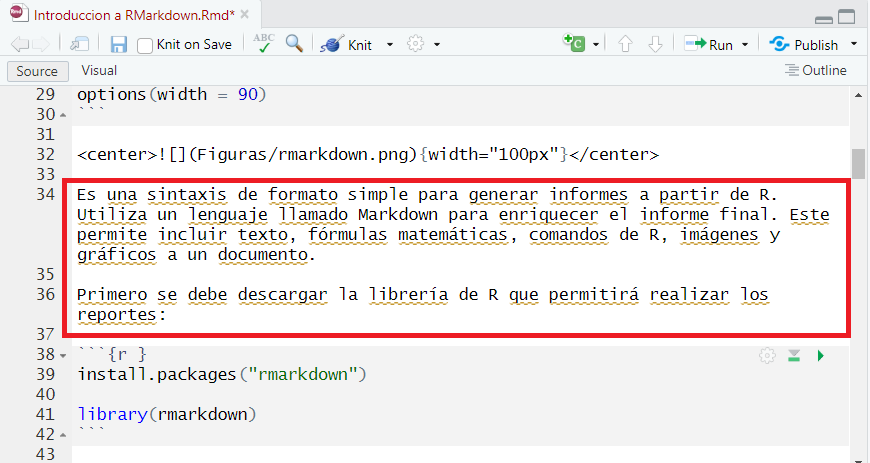

### El código

Los fragmentos de códigos **chunk** se escriben entre un par de tres comiñas,```. Hay diferentes opciones de lenguajes posibles de usar. Comúnmente se utiliza R que es en donde estamos trabajando.

[figure not shown]

Aquí es dónde vamos a escribir todo el código de R.

[figure not shown]

Para establecer opciones globales que se apliquen a cada chunk del archivo, se puede configurar un primer chunk llamando a **knitr::opts_chunk$set**. Knitr utilizará cada opción que se le indique a knitr::opts_chunk$set como una opción global predeterminada, que puede sobrescribirse en los encabezados de cada chunk.

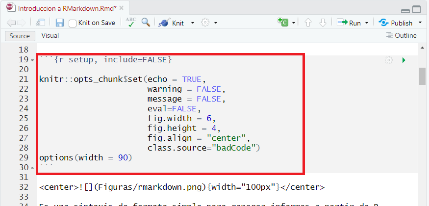

Algunos argumentos que pueden ser utilizados para configurar los chunks:

- include = FALSE: evita que el código y los resultados aparezcan en el reporte. Este código se ejecuta y los resultados pueden ser utilizados por otros fragmentos.
- echo = FALSE: evita que el código, pero no los resultados, aparezcan en el reporte. Esta es una forma útil de incrustar figuras.
- message = FALSE: evita que los mensajes generados por código aparezcan en el reporte.
- warning = FALSE: evita que las advertencias generadas por el código aparezcan.
- fig.cap = “…”: agrega un título a los resultados gráficos.

## Diferentes formatos de texto

La sintaxis para el texto es Markdown. Cualquier texto que se incluya en el informe aparecerá tal cual. Si queremos incluir títulos, subtítulos, caracteres en negrita, caracteres en cursiva o ecuaciones matemáticas, tendremos que introducir una sintaxis específica. Veamos algunos ejemplos:

Para introducir títulos, subtítulos, y encabezados podemos usar el carácter # .

```r
# Título
## Subtítulo
### Subsubtítulo
```

Para resaltar una palabra (o frase) en negrita debemos ponerla entre doble asterisco (**).

```r
Esta frase está en **negrita**
```

Esta frase está en **negrita**

Para poner una palabra (o frase) en cursiva debemos ponerla entre asteriscos simples (*)

```r
Esta frase está en *letras cursivas*
```

Esta frase está en *letras cursivas*

```r
* Primer ítem
* Segundo ítem
* Tercer ítem
```

- Primer ítem
- Segundo ítem
- Tercer ítem

Para incluir fórmulas matemáticas en R Markdown se basa en la sintaxis del sistema de LATEX (composición de textos científicos).

El código para fórmulas o ecuaciones se escriben entre signos pesos ($):

```r
$x^2+y^2=4$
```

$x^2+y^2=4$

Para que la ecuación quede centrada se debe usar doble signo peso $$.

```r
$$x^2+y^2=4$$
```

$$x^2+y^2=4$$

## Insertar un link

Para agregar un link, puedes simplemente poner el link o ajustar un nombre al link.

```r
[Guía de R Markdown](https://bookdown.org/yihui/rmarkdown/)
```

[Guía de R Markdown](https://bookdown.org/yihui/rmarkdown/)

## Insertar una imágen

La manera de insertar una imagen es la siguiente.

```r
<center>
![Título de la imagen](Figuras/Guia RMarkdown.jpg){width="100px" height="200px"}
</center>
```

## Tablas

### Librería knitr

```r
library(knitr)
dt <- mtcars[1:5, 1:6]
kable(dt, caption = "Tabla autos")
```

Tabla autos

|  | mpg | cyl | disp | hp | drat | wt |
| --- | --- | --- | --- | --- | --- | --- |
| Mazda RX4 | 21.0 | 6 | 160 | 110 | 3.90 | 2.620 |
| Mazda RX4 Wag | 21.0 | 6 | 160 | 110 | 3.90 | 2.875 |
| Datsun 710 | 22.8 | 4 | 108 | 93 | 3.85 | 2.320 |
| Hornet 4 Drive | 21.4 | 6 | 258 | 110 | 3.08 | 3.215 |
| Hornet Sportabout | 18.7 | 8 | 360 | 175 | 3.15 | 3.440 |

```r
dt %>%
  kbl() %>%
  kable_paper("hover",
              full_width = F)
```

|  | mpg | cyl | disp | hp | drat | wt |
| --- | --- | --- | --- | --- | --- | --- |
| Mazda RX4 | 21.0 | 6 | 160 | 110 | 3.90 | 2.620 |
| Mazda RX4 Wag | 21.0 | 6 | 160 | 110 | 3.90 | 2.875 |
| Datsun 710 | 22.8 | 4 | 108 | 93 | 3.85 | 2.320 |
| Hornet 4 Drive | 21.4 | 6 | 258 | 110 | 3.08 | 3.215 |
| Hornet Sportabout | 18.7 | 8 | 360 | 175 | 3.15 | 3.440 |

```r
dt %>%
  kbl() %>%
  kable_material_dark()
```

[output not shown]

[Opciones de tablas con knitr::kable y kableExtra](https://cran.r-project.org/web/packages/kableExtra/vignettes/awesome_table_in_html.html)

### Librería DT

Las tablas de DT son más aptas para tablas grandes

```r
properati1 <- properati %>% select(place_name, price, year)

properati5 <- properati1 %>%
               group_by(place_name) %>%
               summarise(promedio_precio = round(mean(price), 2),
                         min_precio = round(min(price),2),
                         max_precio = round(max(price), 2))

DT::datatable(properati5)
```

|  | place_name | promedio_precio | min_precio | max_precio |
| --- | --- | --- | --- | --- |
| 1 | Abasto | 89833.33 | 75000 | 107000 |
| 2 | Adrogué | 230000 | 230000 | 230000 |
| 3 | Agronomia | 192560.23 | 66500 | 540000 |
| 4 | Almagro | 131086.4 | 47000 | 470000 |
| 5 | Avellaneda | 121666.67 | 70000 | 170000 |
| 6 | Balvanera | 177502.56 | 42900 | 2200000 |
| 7 | Barracas | 172875.95 | 45800 | 450000 |
| 8 | Barrio Norte | 372403.49 | 56900 | 3200000 |
| 9 | Belgrano | 326868.13 | 30000 | 3300000 |
| 10 | Berazategui | 480000 | 480000 | 480000 |

[output cut: 87 more lines]

```r
DT::datatable(properati5,
              options = list(
                      pageLength = 5,
                      language = list(url = '//cdn.datatables.net/plug-ins/1.10.11/i18n/Spanish.json')
              )
    )
```

|  | place_name | promedio_precio | min_precio | max_precio |
| --- | --- | --- | --- | --- |
| 1 | Abasto | 89833.33 | 75000 | 107000 |
| 2 | Adrogué | 230000 | 230000 | 230000 |
| 3 | Agronomia | 192560.23 | 66500 | 540000 |
| 4 | Almagro | 131086.4 | 47000 | 470000 |
| 5 | Avellaneda | 121666.67 | 70000 | 170000 |
| 6 | Balvanera | 177502.56 | 42900 | 2200000 |
| 7 | Barracas | 172875.95 | 45800 | 450000 |
| 8 | Barrio Norte | 372403.49 | 56900 | 3200000 |
| 9 | Belgrano | 326868.13 | 30000 | 3300000 |
| 10 | Berazategui | 480000 | 480000 | 480000 |

[output cut: 87 more lines]

```r
DT::datatable(properati5,
                    extensions = 'FixedColumns',
                    rownames= FALSE,
                    filter = 'top',
                    options = list(
                      pageLength = 5,
                      language = list(url = '//cdn.datatables.net/plug-ins/1.10.11/i18n/Spanish.json'))
                      # autoWidth = TRUE,
                      # escape = T)
              )
```

| place_name | promedio_precio | min_precio | max_precio |
| --- | --- | --- | --- |
| Abasto | 89833.33 | 75000 | 107000 |
| Adrogué | 230000 | 230000 | 230000 |
| Agronomia | 192560.23 | 66500 | 540000 |
| Almagro | 131086.4 | 47000 | 470000 |
| Avellaneda | 121666.67 | 70000 | 170000 |
| Balvanera | 177502.56 | 42900 | 2200000 |
| Barracas | 172875.95 | 45800 | 450000 |
| Barrio Norte | 372403.49 | 56900 | 3200000 |
| Belgrano | 326868.13 | 30000 | 3300000 |
| Berazategui | 480000 | 480000 | 480000 |

[output cut: 87 more lines]

## Referencias:

[Introducción a RMarkdown](https://rpubs.com/JairoAyala/RMarkdown)

[Introducción a RMarkdown en español](https://rpubs.com/tereboca/informe_rmakrdown)